# Class Notes 3.28.35 - 04.02.25

```r
library(tidyverse)
library(readxl)
library(modeldata)

pokemon <- read_csv("pokemon (1).csv")
trout <- read_excel("trout.xlsx")
```

Merges: combine two files that you have been working on

## Git

We talked about branches a bit. See my video on git branches and merges.

## Anova

When to use Anova:  
Inference with 2 variables 1. 2 categorical (x^2)  
2. 2 quantitative (regression)  
3. 1 categorical and 1 quantitative (anova)

We’ll use the `pokemon` data set from Moodle. Also see my slide on anova on Moodle.

Is `hp` consistent, on average, across generations?

Null: the mean hp is the same for each generation (independent).

Alternative: the mean hp is different for at least one generation (dependence).

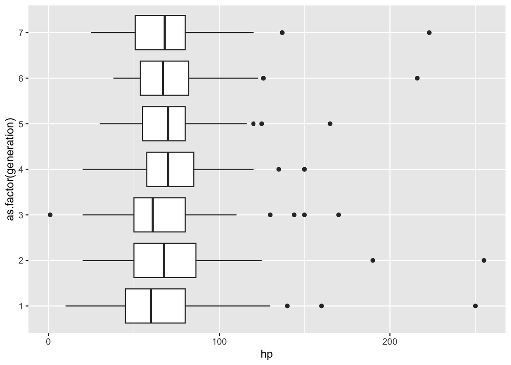

```r
ggplot(pokemon,
       aes(x = hp,
           y = as.factor(generation))) + #as.character() also works here
  geom_boxplot()
```

To run the test, we need `generation` to be categorical, so we do a `mutate` before the anova.

```r
pokemon <- pokemon %>%
  mutate(generation = as.factor(generation))

aov(pokemon$hp ~ pokemon$generation)
```

```
Call:
   aov(formula = pokemon$hp ~ pokemon$generation)

Terms:
                pokemon$generation Residuals
Sum of Squares              7753.4  557274.2
Deg. of Freedom                  6       794

Residual standard error: 26.49258
Estimated effects may be unbalanced
```

To see the p-value, we save this output and then get a `summary`.

```r
model <- aov(hp ~ generation,
             data = pokemon) # same aov
summary(model)
```

```
             Df Sum Sq Mean Sq F value Pr(>F)
generation    6   7753  1292.2   1.841 0.0884 .
Residuals   794 557274   701.9
---
Signif. codes:  0 '***' 0.001 '**' 0.01 '*' 0.05 '.' 0.1 ' ' 1
```

The p-value (.088) is not very small. There is only very weak evidence that the variables are dependent on one another. It appears that `generation` does not inform `hp`.

## Example 2: trout

```r
glimpse(trout)
```

```
Rows: 40
Columns: 2
$ Location <dbl> 1, 1, 1, 1, 1, 1, 1, 1, 1, 1, 2, 2, 2, 2, 2, 2, 2, 2, 2, 2, 3…
$ Hemo     <dbl> 6.7, 7.8, 5.5, 8.4, 7.0, 7.8, 8.6, 7.4, 5.8, 7.0, 9.9, 8.4, 1…
```

Are these variables independent?

$H_0:$ `Hemo` is the same at different locations, on average.

$H_a:$ At least one group mean is different.

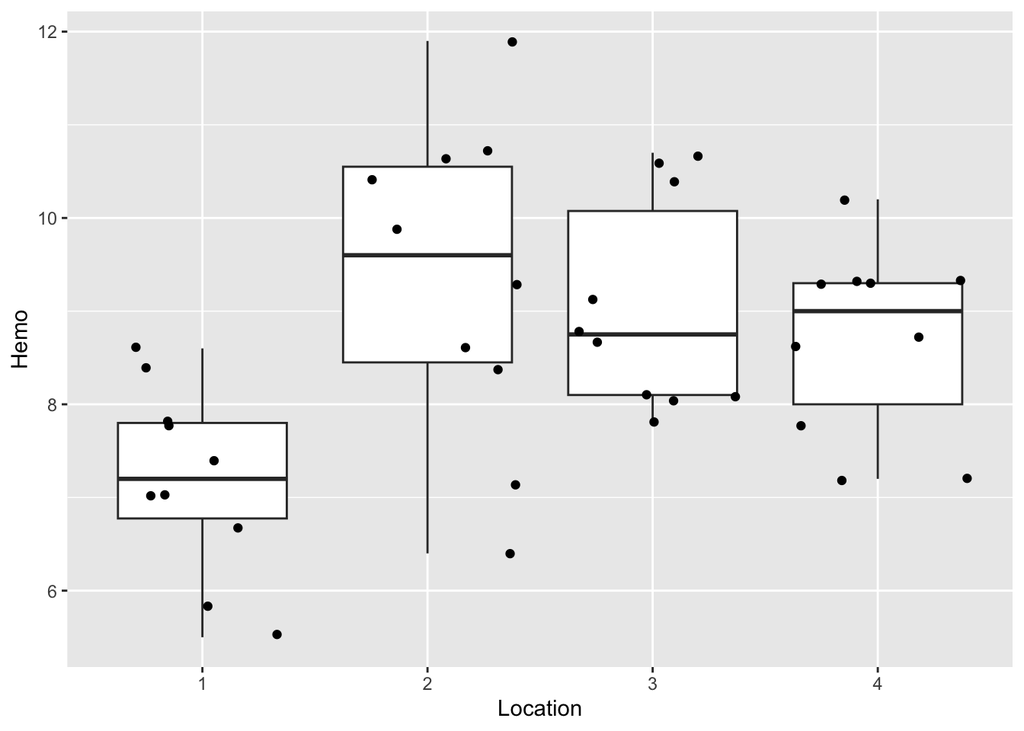

```r
trout <- trout %>%
  mutate(Location = as.factor(Location))

ggplot(trout,
       aes(x = Location,
           y = Hemo)) +
  geom_boxplot() +
  geom_jitter()
```

Let’s run the anova.

```r
model <- aov(Hemo ~ Location,
             data = trout)
summary(model)
```

```
            Df Sum Sq Mean Sq F value  Pr(>F)
Location     3  26.80   8.934   5.696 0.00268 **
Residuals   36  56.47   1.569
---
Signif. codes:  0 '***' 0.001 '**' 0.01 '*' 0.05 '.' 0.1 ' ' 1
```

The p-value is very small, providing good evidence against the null. We can conclude that Hemo is informed by Location.

(Last thing today: commit changes to the git repo)

## Apr. 2: Post-hoc testing

If the anova leads to rejecting the null, we can consider pair-wise comparisons of the groups. HOWEVER, we have to be honest about the fact that there are many possible comparisons. One very common way to do this is the **Tukey Honest Standard Differences Test**.

```r
TukeyHSD(model)
```

```
  Tukey multiple comparisons of means
    95% family-wise confidence level

Fit: aov(formula = Hemo ~ Location, data = trout)

$Location
     diff         lwr       upr     p adj
2-1  2.13  0.62148556 3.6385144 0.0028743
3-1  1.83  0.32148556 3.3385144 0.0122308
4-1  1.49 -0.01851444 2.9985144 0.0539172
3-2 -0.30 -1.80851444 1.2085144 0.9497752
4-2 -0.64 -2.14851444 0.8685144 0.6660242
4-3 -0.34 -1.84851444 1.1685144 0.9291864
```

## Comparing two quantitative variables

```r
glimpse(crickets)
```

```
Rows: 31
Columns: 3
$ species <fct> O. exclamationis, O. exclamationis, O. exclamationis, O. excla…
$ temp    <dbl> 20.8, 20.8, 24.0, 24.0, 24.0, 24.0, 26.2, 26.2, 26.2, 26.2, 28…
$ rate    <dbl> 67.9, 65.1, 77.3, 78.7, 79.4, 80.4, 85.8, 86.6, 87.5, 89.1, 98…
```

Null hypothesis: `rate` is independent of `temp`.

Alternative: `rate` is not independent of `temp`.

More specifically, we’ll test for a linear dependence. That is, we’ll test if the slope of regression line is nonzero.

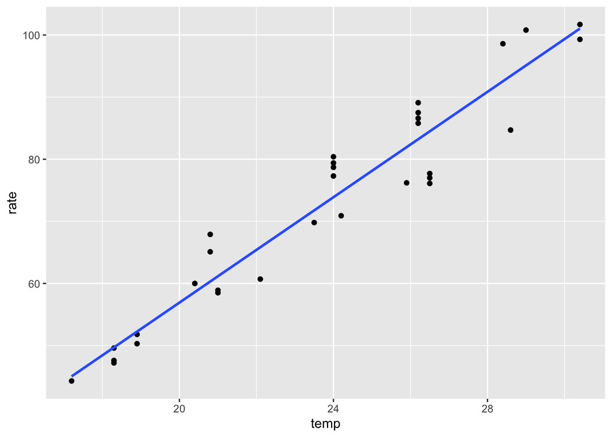

```r
ggplot(crickets,
       aes(x = temp,
           y = rate)) +
  geom_point() +
  geom_smooth(method = "lm",
              se = FALSE)
```

More specific hypothesis:

Null: the slope is zero in the population from which we are sampling.

Alternative: the slope is nonzero

Let’s run this test.

```r
lm(rate ~ temp,
   data = crickets) # syntax just like aov
```

```
Call:
lm(formula = rate ~ temp, data = crickets)

Coefficients:
(Intercept)         temp
    -27.948        4.243
```

The equation of the regression line rate = -27.948 + 4.243*temp. We extract more information (including a p-value for our test) by saving the model and getting a summary.

```r
model <- lm(rate ~ temp,
   data = crickets)
summary(model)
```

```
Call:
lm(formula = rate ~ temp, data = crickets)

Residuals:
    Min      1Q  Median      3Q     Max
-8.7044 -2.5789 -0.4466  4.5353  7.5916

Coefficients:
            Estimate Std. Error t value Pr(>|t|)
(Intercept) -27.9476     5.5937  -4.996 2.56e-05 ***
temp          4.2431     0.2325  18.251  < 2e-16 ***
---
Signif. codes:  0 '***' 0.001 '**' 0.01 '*' 0.05 '.' 0.1 ' ' 1

Residual standard error: 4.868 on 29 degrees of freedom
Multiple R-squared:  0.9199,    Adjusted R-squared:  0.9171
F-statistic: 333.1 on 1 and 29 DF,  p-value: < 2.2e-16
```

The p-value for the slope is infinitesimal. We reject the null and conclude there is a non-zero slope, that rate is dependent on temp.